# Ejercicio 1 — Monte Carlo e Importance Sampling

**Máster Executive en Finanzas Cuantitativas 2026 · AFI Global Education**  
**Asignatura:** Fundamentos Matemáticos — Probabilidad y Simulación

## Objetivo

Queremos estimar la integral:

$$I = \int_0^1 g(x)\, dx = \int_0^1 \cos\!\left(\frac{\pi x}{2}\right) dx$$

mediante tres métodos, comparando su precisión y eficiencia:

1. **Cálculo analítico** — valor exacto de referencia.
2. **Monte Carlo directo** — muestreo uniforme $X\sim U(0,1)$.
3. **Importance Sampling (muestreo por importancia)** — con la densidad auxiliar $\tilde{f}(x) = \lambda(1 - x^2)$, que aproxima a $g$.

Finalmente (apartado 1c) compararemos la **varianza** de ambos estimadores Monte Carlo para cuantificar la reducción de varianza que aporta el Importance Sampling.

> **Nota de reproducibilidad.** Todas las celdas usan semillas fijas, de modo que los números que aparecen en el texto y en las conclusiones se corresponden exactamente con los que produce el código al ejecutarse.

### Configuración del entorno

Centralizamos en una sola celda las librerías, el estilo gráfico, las constantes del problema y las semillas. Así el resto del notebook queda limpio y todo el cuaderno es reproducible.

```python
import numpy as np
import matplotlib.pyplot as plt
from scipy import integrate

# Estilo gráfico coherente para todo el notebook
plt.rcParams.update({
    "figure.dpi": 110,
    "font.size": 11,
    "axes.grid": True,
    "grid.alpha": 0.3,
    "axes.titleweight": "bold",
})

# ── Constantes del problema ──────────────────────────────────────────────────
LAMBDA  = 3/2          # constante de normalización de f̃ (se justifica en 1a)
I_EXACTO = 2/np.pi     # valor analítico de la integral (se deduce en 1b)
N = 200                # tamaño muestral pedido en el enunciado

# ── Funciones del problema ───────────────────────────────────────────────────
def g(x):
    """Integrando objetivo g(x) = cos(πx/2)."""
    return np.cos(np.pi * x / 2)

def f_tilde(x):
    """Densidad auxiliar de importance sampling f̃(x) = 3/2·(1−x²) en (0,1)."""
    return LAMBDA * (1 - x**2)

print(f"λ        = {LAMBDA}")
print(f"I exacto = 2/π = {I_EXACTO:.6f}")
print(f"n        = {N}")
```

```
λ        = 1.5
I exacto = 2/π = 0.636620
n        = 200
```

## Apartado 1a — Determinación de λ

### Motivación del Importance Sampling

En Monte Carlo directo estimamos:

$$I = \int_0^1 g(x)\, dx = \mathbb{E}_{X \sim U(0,1)}[g(X)]$$

La idea del **muestreo por importancia** es que, si disponemos de una densidad $\tilde{f}$ que se parece a $g$, podemos reescribir la integral como:

$$I = \int_0^1 \frac{g(x)}{\tilde{f}(x)}\, \tilde{f}(x)\, dx = \mathbb{E}_{X \sim \tilde{f}}\!\left[\frac{g(X)}{\tilde{f}(X)}\right]$$

Si $\tilde{f}$ es aproximadamente proporcional a $g$, el cociente $g/\tilde{f}$ es casi constante y la varianza del estimador se reduce drásticamente (esto lo verificaremos en 1c).

### Elección de la forma de $\tilde{f}$

Aproximamos $g$ por un polinomio de segundo grado que respete las propiedades de $g$ en el intervalo:

- $g(0) = \cos(0) = 1$ (máximo en el origen)
- $g(1) = \cos(\pi/2) = 0$ (se anula en el extremo)
- $g$ es **par** ($\cos$ es par), por lo que la aproximación no debe tener término lineal

Esto conduce a la forma $\tilde{f}(x) = \lambda(1 - x^2)$, que vale $\lambda$ en $x=0$ y $0$ en $x=1$, igual que $g$ (salvo escala).

### Cálculo de λ

Para que $\tilde{f}$ sea una **función de densidad** en $(0,1)$ debe ser no negativa (lo es, pues $1-x^2\ge 0$ en $(0,1)$ y $\lambda>0$) e integrar 1:

$$\int_0^1 \lambda(1 - x^2)\, dx = \lambda \left[x - \frac{x^3}{3}\right]_0^1 = \lambda \left(1 - \frac{1}{3}\right) = \lambda \cdot \frac{2}{3} = 1$$

$$\boxed{\lambda = \frac{3}{2}}$$

```python
# Verificación numérica: f̃ debe integrar exactamente 1 en (0,1)
integral_check, _ = integrate.quad(f_tilde, 0, 1)
print(f"λ = {LAMBDA}")
print(f"∫₀¹ λ(1−x²) dx = {integral_check:.10f}")
assert abs(integral_check - 1) < 1e-12, "f̃ no integra 1: λ incorrecto"
print("✓ f̃ es una densidad válida en (0,1)")
```

```
λ = 1.5
∫₀¹ λ(1−x²) dx = 1.0000000000
✓ f̃ es una densidad válida en (0,1)
```

## Apartado 1b — Cálculo de la integral por tres métodos

### Método 1 · Valor analítico

$$I = \int_0^1 \cos\!\left(\frac{\pi x}{2}\right) dx = \left[\frac{2}{\pi}\sin\!\left(\frac{\pi x}{2}\right)\right]_0^1 = \frac{2}{\pi}\sin\!\left(\frac{\pi}{2}\right) - \frac{2}{\pi}\sin(0) = \frac{2}{\pi}$$

$$\boxed{I = \frac{2}{\pi} \approx 0.636620}$$

```python
# Valor analítico y verificación con integración numérica determinista
I_scipy, _ = integrate.quad(g, 0, 1)
print(f"Valor analítico:      I = 2/π   = {I_EXACTO:.6f}")
print(f"Verificación (scipy): I = quad  = {I_scipy:.6f}")
assert abs(I_EXACTO - I_scipy) < 1e-10
```

```
Valor analítico:      I = 2/π   = 0.636620
Verificación (scipy): I = quad  = 0.636620
```

### Método 2 · Monte Carlo directo

Expresamos la integral como esperanza bajo la distribución uniforme (aquí la densidad de $X$ es $f(x)=1$ en $(0,1)$):

$$I = \int_0^1 g(x)\, \underbrace{f(x)}_{=1}\, dx = \mathbb{E}_{X \sim U(0,1)}[g(X)]$$

El estimador Monte Carlo con $n = 200$ observaciones es la media muestral:

$$\hat{I}_{MC} = \frac{1}{n} \sum_{i=1}^n g(X_i), \qquad X_i \overset{\text{iid}}{\sim} U(0,1)$$

```python
# RNG dedicado y reproducible para la estimación puntual de 1b
rng_pt = np.random.default_rng(42)

# 1) n muestras uniformes U(0,1)
X_mc = rng_pt.uniform(0, 1, N)
# 2) evaluamos g en cada muestra
g_mc = g(X_mc)
# 3) el estimador es la media de g(X)
I_mc = g_mc.mean()

print(f"Monte Carlo directo (n={N}):")
print(f"  Estimación      Î_MC = {I_mc:.6f}")
print(f"  Error absoluto       = {abs(I_mc - I_EXACTO):.6f}")
```

```
Monte Carlo directo (n=200):
  Estimación      Î_MC = 0.646076
  Error absoluto       = 0.009457
```

### Método 3 · Importance Sampling con $\tilde{f}(x) = \frac{3}{2}(1-x^2)$

Usando la reformulación del apartado 1a, el estimador es:

$$\hat{I}_{IS} = \frac{1}{n}\sum_{i=1}^n \underbrace{\frac{g(X_i)}{\tilde{f}(X_i)}}_{\text{pesos } w_i}, \qquad X_i \overset{\text{iid}}{\sim} \tilde{f}$$

El reto es **generar muestras de $\tilde{f}$**. Usamos el método de la **transformada inversa**.

#### Inversión de la CDF

La función de distribución de $\tilde{f}$ es:

$$F(x) = \int_0^x \frac{3}{2}(1-t^2)\, dt = \frac{3}{2}\left(x - \frac{x^3}{3}\right) = \frac{3x - x^3}{2}$$

Para simular $X\sim\tilde f$ generamos $u\sim U(0,1)$ y resolvemos $F(x)=u$:

$$\frac{3x - x^3}{2} = u \;\Longrightarrow\; x^3 - 3x + 2u = 0$$

una **ecuación cúbica** de la forma reducida $x^3 + px + q = 0$ con $p = -3,\; q = 2u$.

#### Fórmula de Cardano — caso de tres raíces reales

El discriminante de la cúbica reducida es $D = \left(\tfrac{q}{2}\right)^2 + \left(\tfrac{p}{3}\right)^3 = u^2 - 1$. Como $u\in(0,1)$, se tiene $D = u^2-1 < 0$: estamos en el **casus irreducibilis** (tres raíces reales distintas), y conviene la **forma trigonométrica** de Cardano:

$$x_k = 2\sqrt{-\frac{p}{3}}\,\cos\!\left(\frac{1}{3}\arccos\!\left(\frac{3q}{2p}\sqrt{\frac{-3}{p}}\right) - \frac{2\pi k}{3}\right), \quad k = 0, 1, 2$$

Sustituyendo $p=-3,\; q=2u$ se simplifica notablemente ($\sqrt{-p/3}=1$ y el argumento del $\arccos$ es $-u$):

$$x_k = 2\cos\!\left(\frac{\arccos(-u)}{3} - \frac{2\pi k}{3}\right), \quad k=0,1,2$$

#### Elección de la rama

El enunciado pide *elegir una rama de las raíces*. De las tres, solo una cae en el soporte $(0,1)$. Lo comprobamos numéricamente en la siguiente celda: la rama válida es $k=1$,

$$\boxed{x = 2\cos\!\left(\frac{\arccos(-u)}{3} - \frac{2\pi}{3}\right)}$$

```python
def cardano_raiz(u, k=1):
    """
    Resuelve x³ - 3x + 2u = 0 mediante la forma trigonométrica de Cardano.
    Devuelve la raíz de índice k (por defecto k=1, la única en (0,1)).
    """
    theta = np.arccos(-u)                       # ∈ (π/2, π) para u ∈ (0,1)
    return 2 * np.cos(theta/3 - 2*np.pi*k/3)

# Justificación de la elección de rama: ubicamos las TRES raíces para varios u
print("Ubicación de las tres raíces de Cardano según u:")
print(f"{'u':>6} | {'k=0':>9} {'k=1':>9} {'k=2':>9}   ← solo k=1 ∈ (0,1)")
print("-" * 50)
for u in [0.01, 0.25, 0.50, 0.75, 0.99]:
    r = [cardano_raiz(u, k) for k in range(3)]
    print(f"{u:>6.2f} | {r[0]:>9.4f} {r[1]:>9.4f} {r[2]:>9.4f}")
print()
print("k=0 → rama en (1, 2)  |  k=1 → rama en (0, 1) ✓  |  k=2 → rama en (−2, −1)")
```

```
Ubicación de las tres raíces de Cardano según u:
     u |       k=0       k=1       k=2   ← solo k=1 ∈ (0,1)
--------------------------------------------------
  0.01 |    1.7287    0.0067   -1.7354
  0.25 |    1.6418    0.1683   -1.8100
  0.50 |    1.5321    0.3473   -1.8794
  0.75 |    1.3844    0.5579   -1.9422
  0.99 |    1.0806    0.9172   -1.9978

k=0 → rama en (1, 2)  |  k=1 → rama en (0, 1) ✓  |  k=2 → rama en (−2, −1)
```

```python
# Verificación de que la inversión es exacta: F(F⁻¹(u)) = u
u_test = np.array([0.1, 0.3, 0.5, 0.7, 0.9])
x_test = cardano_raiz(u_test)
F_test = (3*x_test - x_test**3) / 2

print("Verificación de la inversión de la CDF:")
print(f"{'u':>6}  {'x = F⁻¹(u)':>12}  {'F(x)':>10}  {'|F(x)-u|':>10}")
for u_, x_, f_ in zip(u_test, x_test, F_test):
    print(f"{u_:6.2f}  {x_:12.6f}  {f_:10.6f}  {abs(f_-u_):10.2e}")
```

```
Verificación de la inversión de la CDF:
     u    x = F⁻¹(u)        F(x)    |F(x)-u|
  0.10      0.066766    0.100000    1.03e-15
  0.30      0.202779    0.300000    1.11e-15
  0.50      0.347296    0.500000    7.77e-16
  0.70      0.511195    0.700000    3.33e-16
  0.90      0.729299    0.900000    3.33e-16
```

```python
# Generación de n muestras de f̃ por transformada inversa + estimador IS
U_is = rng_pt.uniform(0, 1, N)
X_is = cardano_raiz(U_is)

# Comprobación defensiva: todas las muestras deben caer en el soporte (0,1)
assert np.all((X_is > 0) & (X_is < 1)), "Hay muestras fuera de (0,1): rama incorrecta"

# Pesos de importancia w_i = g(X_i) / f̃(X_i)
pesos_is = g(X_is) / f_tilde(X_is)
I_is = pesos_is.mean()

print(f"Importance Sampling (n={N}):")
print(f"  Estimación      Î_IS = {I_is:.6f}")
print(f"  Error absoluto       = {abs(I_is - I_EXACTO):.6f}")
print(f"  Rango de los pesos   = [{pesos_is.min():.4f}, {pesos_is.max():.4f}]  (muy estrecho ⇒ baja varianza)")
```

```
Importance Sampling (n=200):
  Estimación      Î_IS = 0.637154
  Error absoluto       = 0.000535
  Rango de los pesos   = [0.5479, 0.6667]  (muy estrecho ⇒ baja varianza)
```

#### Validación visual del muestreo (Cardano + transformada inversa)

Antes de fiarnos del estimador, comprobamos que las muestras generadas con Cardano **realmente siguen la densidad $\tilde f$**. Si el histograma de las muestras se ajusta a la curva teórica $\tilde f(x)=\frac32(1-x^2)$, el muestreo es correcto.

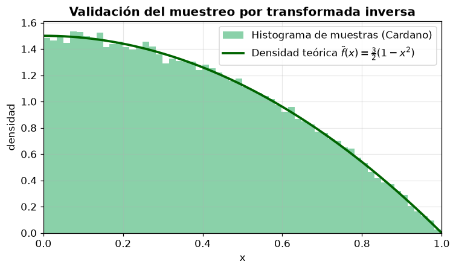

```python
# Usamos muchas muestras solo para que el histograma sea nítido (no afecta a 1b)
X_big = cardano_raiz(np.random.default_rng(7).uniform(0, 1, 100_000))

fig, ax = plt.subplots(figsize=(7, 4.2))
ax.hist(X_big, bins=60, density=True, alpha=0.6, color="mediumseagreen",
        label="Histograma de muestras (Cardano)")
xs = np.linspace(0, 1, 400)
ax.plot(xs, f_tilde(xs), color="darkgreen", lw=2.5,
        label=r"Densidad teórica $\tilde{f}(x)=\frac{3}{2}(1-x^2)$")
ax.set(xlabel="x", ylabel="densidad", xlim=(0, 1),
       title="Validación del muestreo por transformada inversa")
ax.legend()
plt.tight_layout()
plt.savefig("resultados/grafico_validacion_muestreo.png", dpi=150, bbox_inches="tight")
plt.show()
```

```python
# Resumen comparativo de los tres métodos (apartado 1b)
print("=" * 56)
print("COMPARATIVA DE MÉTODOS  (apartado 1b, n = 200)")
print("=" * 56)
print(f"{'Método':<24}{'Estimación':>14}{'Error abs.':>14}")
print("-" * 56)
print(f"{'Analítico (2/π)':<24}{I_EXACTO:>14.6f}{'—':>14}")
print(f"{'Monte Carlo directo':<24}{I_mc:>14.6f}{abs(I_mc-I_EXACTO):>14.6f}")
print(f"{'Importance Sampling':<24}{I_is:>14.6f}{abs(I_is-I_EXACTO):>14.6f}")
```

```
========================================================
COMPARATIVA DE MÉTODOS  (apartado 1b, n = 200)
========================================================
Método                      Estimación    Error abs.
--------------------------------------------------------
Analítico (2/π)               0.636620             —
Monte Carlo directo           0.646076      0.009457
Importance Sampling           0.637154      0.000535
```

## Apartado 1c — Comparación de varianzas

Cada estimación basada en $n$ muestras es, en sí misma, una realización de una variable aleatoria. Por ser medias muestrales de términos iid:

$$\text{Var}(\hat{I}_{MC}) = \frac{\sigma^2_{MC}}{n}, \qquad \text{Var}(\hat{I}_{IS}) = \frac{\sigma^2_{IS}}{n}$$

donde las varianzas **por observación** son:

$$\sigma^2_{MC} = \text{Var}_{U}\big(g(X)\big) = \int_0^1 g(x)^2\, dx - I^2, \qquad \sigma^2_{IS} = \text{Var}_{\tilde{f}}\!\left(\frac{g(X)}{\tilde{f}(X)}\right) = \int_0^1 \frac{g(x)^2}{\tilde{f}(x)}\, dx - I^2$$

### Cálculo analítico

**MC directo** — usando $\cos^2\theta = \tfrac{1+\cos 2\theta}{2}$:

$$\int_0^1 \cos^2\!\left(\frac{\pi x}{2}\right)dx = \int_0^1 \frac{1 + \cos(\pi x)}{2}\, dx = \frac{1}{2}\;\Longrightarrow\; \sigma^2_{MC} = \frac{1}{2} - \left(\frac{2}{\pi}\right)^2 = \frac{1}{2} - \frac{4}{\pi^2}$$

**Importance Sampling** — el integrando $\dfrac{g(x)^2}{\tilde f(x)}$ no tiene primitiva elemental sencilla; lo evaluamos numéricamente. Nótese que cerca de $x=1$ tanto $g(x)^2$ como $1-x^2$ tienden a 0, y el cociente permanece **finito** (de hecho $\to 0$), por lo que la integral converge y la varianza es pequeña.

### ¿Por qué el Importance Sampling reduce la varianza? — intuición de los pesos

La clave está en qué se promedia en cada método:

- **MC directo** promedia $g(X)$, que recorre **todo** el rango $[0, 1]$ (de $\cos(\pi/2)=0$ a $\cos 0=1$). Mucha dispersión.
- **IS** promedia los pesos $w(X)=g(X)/\tilde f(X)$, confinados al rango estrecho $[\,\pi/6,\; 2/3\,]\approx[0.524,\,0.667]$, porque $\tilde f$ imita la forma de $g$.

Cuanto menos varía la cantidad que se promedia, menor es la varianza del promedio. Lo veremos numéricamente y, después, gráficamente.

```python
# ── Varianzas teóricas por observación ───────────────────────────────────────
var_mc_teorica = 0.5 - 4/np.pi**2                       # forma cerrada exacta

E_w2_is, _ = integrate.quad(lambda x: g(x)**2 / f_tilde(x), 0, 1)
var_is_teorica = E_w2_is - I_EXACTO**2                  # numérica (sin forma cerrada)

print("VARIANZAS TEÓRICAS por observación:")
print(f"  σ²_MC = 1/2 − 4/π² = {var_mc_teorica:.6f}")
print(f"  σ²_IS              = {var_is_teorica:.6f}")
print(f"  Ratio σ²_MC / σ²_IS = {var_mc_teorica/var_is_teorica:.2f}×")
print(f"  ⇒ el IS es ≈ {var_mc_teorica/var_is_teorica:.0f}× más eficiente por observación")
```

```
VARIANZAS TEÓRICAS por observación:
  σ²_MC = 1/2 − 4/π² = 0.094715
  σ²_IS              = 0.000991
  Ratio σ²_MC / σ²_IS = 95.59×
  ⇒ el IS es ≈ 96× más eficiente por observación
```

### Estimación 1 · desde la propia muestra de n = 200

Lectura literal del enunciado: con la **única** muestra de 200 observaciones de cada método estimamos la varianza del estimador como $s^2/n$ (con $s^2$ la cuasivarianza muestral) y construimos un intervalo de confianza al 95 %:

$$\widehat{\text{Var}}(\hat I) = \frac{s^2}{n}, \qquad IC_{95\%} = \hat I \pm 1.96\,\frac{s}{\sqrt{n}}$$

```python
# Varianza del estimador estimada con la propia muestra de 200 (s²/n) + IC 95%
def resumen_muestral(valores, nombre):
    n = valores.size
    s2 = valores.var(ddof=1)          # cuasivarianza muestral
    var_est = s2 / n                  # varianza del estimador (media)
    se = np.sqrt(var_est)             # error estándar
    media = valores.mean()
    ic = (media - 1.96*se, media + 1.96*se)
    print(f"{nombre}:")
    print(f"  Î = {media:.6f}   Var(Î)≈s²/n = {var_est:.3e}   SE = {se:.5f}")
    print(f"  IC 95% = [{ic[0]:.5f}, {ic[1]:.5f}]   (anchura = {ic[1]-ic[0]:.5f})")
    return var_est

var_mc_muestral = resumen_muestral(g_mc, "Monte Carlo directo")
print()
var_is_muestral = resumen_muestral(pesos_is, "Importance Sampling")
print()
print(f"El IC del IS es ≈ {np.sqrt(var_mc_muestral/var_is_muestral):.1f}× más estrecho que el del MC directo.")
```

```
Monte Carlo directo:
  Î = 0.646076   Var(Î)≈s²/n = 4.471e-04   SE = 0.02115
  IC 95% = [0.60463, 0.68752]   (anchura = 0.08289)

Importance Sampling:
  Î = 0.637154   Var(Î)≈s²/n = 4.522e-06   SE = 0.00213
  IC 95% = [0.63299, 0.64132]   (anchura = 0.00834)

El IC del IS es ≈ 9.9× más estrecho que el del MC directo.
```

### Estimación 2 · por simulación repetida (B réplicas)

Como sugiere el enunciado, *cada estimación de $I$ es a su vez una simulación de una variable aleatoria*. Repetimos el experimento completo $B=10\,000$ veces y medimos directamente la dispersión (varianza empírica) de los $B$ valores de $\hat I$. Esto debe coincidir con $\sigma^2/n$.

```python
# B réplicas independientes de cada método (vectorizado)
B = 10_000
rng_rep = np.random.default_rng(123)

# Monte Carlo directo: B×n uniformes
X_rep = rng_rep.uniform(0, 1, (B, N))
I_mc_rep = g(X_rep).mean(axis=1)

# Importance Sampling: B×n muestras de f̃ vía Cardano
X_is_rep = cardano_raiz(rng_rep.uniform(0, 1, (B, N)))
I_is_rep = (g(X_is_rep) / f_tilde(X_is_rep)).mean(axis=1)

var_mc_emp = I_mc_rep.var()
var_is_emp = I_is_rep.var()

print(f"VARIANZAS EMPÍRICAS del estimador  (n={N}, B={B:,} réplicas):")
print(f"  Var(Î_MC) empírica = {var_mc_emp:.3e}     teórica σ²_MC/n = {var_mc_teorica/N:.3e}")
print(f"  Var(Î_IS) empírica = {var_is_emp:.3e}     teórica σ²_IS/n = {var_is_teorica/N:.3e}")
print(f"  Ratio empírico Var_MC/Var_IS = {var_mc_emp/var_is_emp:.2f}×")
```

```
VARIANZAS EMPÍRICAS del estimador  (n=200, B=10,000 réplicas):
  Var(Î_MC) empírica = 4.761e-04     teórica σ²_MC/n = 4.736e-04
  Var(Î_IS) empírica = 4.938e-06     teórica σ²_IS/n = 4.954e-06
  Ratio empírico Var_MC/Var_IS = 96.40×
```

### Visualización 1 · por qué baja la varianza (los pesos)

Comparamos las distribuciones de **lo que promedia cada método**: $g(X)$ con $X\sim U$ (MC) frente a $w(X)=g(X)/\tilde f(X)$ con $X\sim\tilde f$ (IS). Ambas tienen la misma media $I=2/\pi$, pero el ancho es radicalmente distinto.

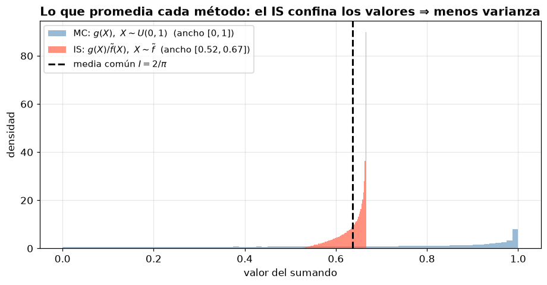

```python
# Muestras grandes solo para visualizar la forma de las distribuciones de los sumandos
rng_v = np.random.default_rng(2024)
g_sum = g(rng_v.uniform(0, 1, 200_000))                       # sumandos de MC
w_sum = (lambda x: g(x)/f_tilde(x))(cardano_raiz(rng_v.uniform(0, 1, 200_000)))  # sumandos de IS

fig, ax = plt.subplots(figsize=(8.5, 4.5))
ax.hist(g_sum, bins=80, density=True, alpha=0.55, color="steelblue",
        label=r"MC: $g(X),\ X\sim U(0,1)$  (ancho $[0,1]$)")
ax.hist(w_sum, bins=80, density=True, alpha=0.7, color="tomato",
        label=r"IS: $g(X)/\tilde{f}(X),\ X\sim\tilde{f}$  (ancho $[0.52,0.67]$)")
ax.axvline(I_EXACTO, color="black", lw=2, ls="--", label=r"media común $I=2/\pi$")
ax.set(xlabel="valor del sumando", ylabel="densidad",
       title="Lo que promedia cada método: el IS confina los valores ⇒ menos varianza")
ax.legend(fontsize=10)
plt.tight_layout()
plt.savefig("resultados/grafico_pesos.png", dpi=150, bbox_inches="tight")
plt.show()
```

### Visualización 2 · función objetivo y distribución de los estimadores

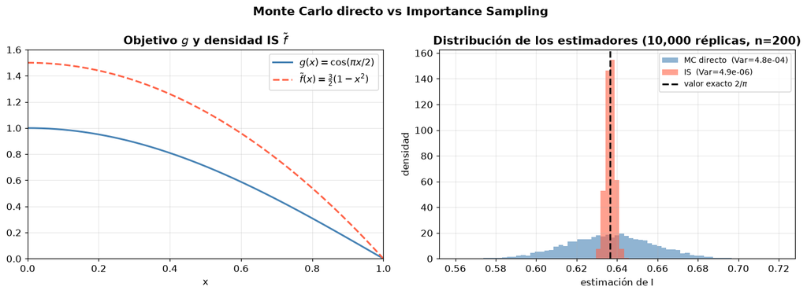

```python
fig, axes = plt.subplots(1, 2, figsize=(13, 4.8))
fig.suptitle("Monte Carlo directo vs Importance Sampling", fontsize=14, fontweight="bold")

# Panel izquierdo: g(x) frente a f̃(x)
ax = axes[0]
xs = np.linspace(0, 1, 400)
ax.plot(xs, g(xs),       lw=2,  color="steelblue", label=r"$g(x)=\cos(\pi x/2)$")
ax.plot(xs, f_tilde(xs), lw=2, ls="--", color="tomato", label=r"$\tilde{f}(x)=\frac{3}{2}(1-x^2)$")
ax.set(xlabel="x", xlim=(0, 1), ylim=(0, 1.6), title="Objetivo $g$ y densidad IS $\\tilde{f}$")
ax.legend()

# Panel derecho: distribución de los B estimadores de cada método
ax2 = axes[1]
bins = np.linspace(0.56, 0.72, 70)
ax2.hist(I_mc_rep, bins=bins, density=True, alpha=0.6, color="steelblue",
         label=f"MC directo  (Var={var_mc_emp:.1e})")
ax2.hist(I_is_rep, bins=bins, density=True, alpha=0.6, color="tomato",
         label=f"IS  (Var={var_is_emp:.1e})")
ax2.axvline(I_EXACTO, color="black", lw=2, ls="--", label="valor exacto $2/\\pi$")
ax2.set(xlabel="estimación de I", ylabel="densidad",
        title=f"Distribución de los estimadores ({B:,} réplicas, n={N})")
ax2.legend(fontsize=9)

plt.tight_layout()
plt.savefig("resultados/grafico_mc_vs_is.png", dpi=150, bbox_inches="tight")
plt.show()
```

### Visualización 3 · convergencia de los estimadores

Mostramos 30 trayectorias independientes de la media acumulada de cada método a medida que crece $n$. El haz del IS es mucho más estrecho y se pega antes al valor exacto: misma convergencia $\mathcal O(1/\sqrt n)$, pero con una constante (la desviación típica) mucho menor.

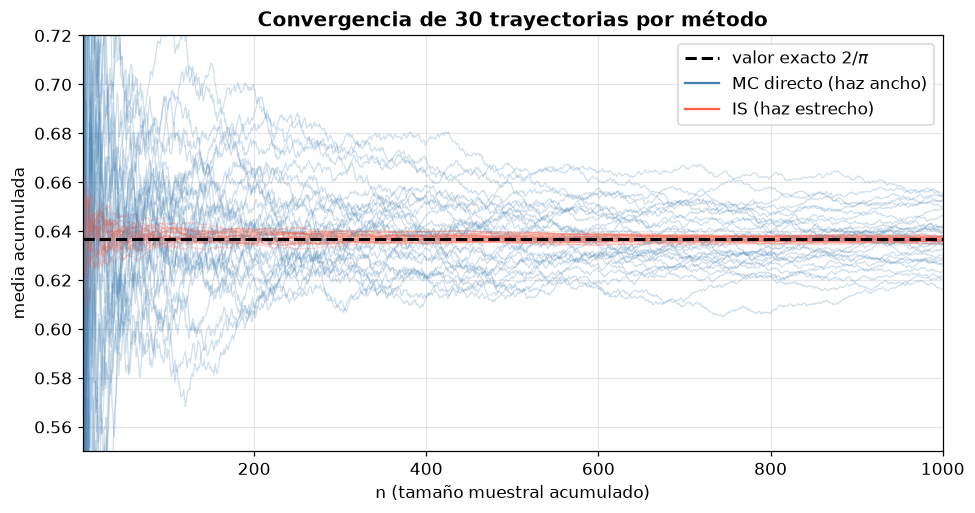

```python
rng_c = np.random.default_rng(99)
n_max, n_traj = 1000, 30
k = np.arange(1, n_max + 1)

fig, ax = plt.subplots(figsize=(9, 4.8))
for j in range(n_traj):
    mc = np.cumsum(g(rng_c.uniform(0, 1, n_max))) / k
    is_ = np.cumsum(g(X := cardano_raiz(rng_c.uniform(0, 1, n_max))) / f_tilde(X)) / k
    ax.plot(k, mc,  color="steelblue", alpha=0.25, lw=0.8)
    ax.plot(k, is_, color="tomato",   alpha=0.25, lw=0.8)
ax.axhline(I_EXACTO, color="black", lw=2, ls="--", label="valor exacto $2/\\pi$")
ax.plot([], [], color="steelblue", label="MC directo (haz ancho)")
ax.plot([], [], color="tomato",    label="IS (haz estrecho)")
ax.set(xlabel="n (tamaño muestral acumulado)", ylabel="media acumulada",
       xlim=(1, n_max), ylim=(0.55, 0.72),
       title=f"Convergencia de {n_traj} trayectorias por método")
ax.legend()
plt.tight_layout()
plt.savefig("resultados/grafico_convergencia.png", dpi=150, bbox_inches="tight")
plt.show()
```

### Tabla resumen final

Generada desde código para garantizar que coincide con las conclusiones.

```python
print("=" * 64)
print("RESUMEN FINAL — Ejercicio 1")
print("=" * 64)
print(f"Valor exacto  I = 2/π = {I_EXACTO:.6f}\n")
print(f"{'':<22}{'MC directo':>18}{'Imp. Sampling':>18}")
print("-" * 64)
print(f"{'Estimación (n=200)':<22}{I_mc:>18.6f}{I_is:>18.6f}")
print(f"{'Error absoluto':<22}{abs(I_mc-I_EXACTO):>18.6f}{abs(I_is-I_EXACTO):>18.6f}")
print(f"{'σ² por obs. (teór.)':<22}{var_mc_teorica:>18.6f}{var_is_teorica:>18.6f}")
print(f"{'Var(Î)=σ²/n (teór.)':<22}{var_mc_teorica/N:>18.3e}{var_is_teorica/N:>18.3e}")
print(f"{'Var(Î) empírica':<22}{var_mc_emp:>18.3e}{var_is_emp:>18.3e}")
print("-" * 64)
print(f"Reducción de varianza (IS frente a MC):  ≈ {var_mc_teorica/var_is_teorica:.1f}× (teórica)"
      f"  /  ≈ {var_mc_emp/var_is_emp:.1f}× (empírica)")
```

```
================================================================
RESUMEN FINAL — Ejercicio 1
================================================================
Valor exacto  I = 2/π = 0.636620

                              MC directo     Imp. Sampling
----------------------------------------------------------------
Estimación (n=200)              0.646076          0.637154
Error absoluto                  0.009457          0.000535
σ² por obs. (teór.)             0.094715          0.000991
Var(Î)=σ²/n (teór.)            4.736e-04         4.954e-06
Var(Î) empírica                4.761e-04         4.938e-06
----------------------------------------------------------------
Reducción de varianza (IS frente a MC):  ≈ 95.6× (teórica)  /  ≈ 96.4× (empírica)
```

## Conclusiones

> Todos los valores numéricos de esta sección proceden directamente de las celdas ejecutadas (semillas fijas).

### Apartado 1a

Para que $\tilde{f}(x) = \lambda(1-x^2)$ sea densidad en $(0,1)$ imponemos $\int_0^1 \tilde{f}=1$, lo que da $\boxed{\lambda = 3/2}$.

### Apartado 1b

| Método | Estimación (n=200) | Error absoluto |
| --- | --- | --- |
| Analítico ($2/\pi$) | 0.636620 | — |
| Monte Carlo directo | 0.646076 | 0.009457 |
| Importance Sampling | 0.637154 | 0.000535 |

Los tres métodos coinciden alrededor de $2/\pi$. Con **las mismas 200 muestras**, el IS comete un error ~18× menor que el MC directo en esta realización. La generación de muestras de $\tilde f$ exigió invertir la CDF resolviendo la cúbica $x^3-3x+2u=0$ con la forma trigonométrica de Cardano, eligiendo la única rama ($k=1$) que cae en $(0,1)$.

### Apartado 1c — Reducción de varianza

| Estimador | $\sigma^2$ por observación | $\text{Var}(\hat I)=\sigma^2/n$ ($n=200$) |
| --- | --- | --- |
| MC directo | $\tfrac{1}{2}-\tfrac{4}{\pi^2} \approx 0.094715$ | $\approx 4.74\times10^{-4}$ |
| IS con $\tilde{f}$ | $\approx 0.000991$ | $\approx 4.95\times10^{-6}$ |

**Sí hay diferencia, y es grande: el Importance Sampling reduce la varianza en un factor ≈ 95.6×** (confirmado por las réplicas: ≈ 96.4× empírico). La razón es que $\tilde{f}(x)=\tfrac{3}{2}(1-x^2)$ imita la forma de $g(x)=\cos(\pi x/2)$, de modo que los pesos $w=g/\tilde f$ apenas varían (rango $[0.524,\,0.667]$) frente a $g(X)$ en MC, que recorre todo $[0,1]$. Menos dispersión en los sumandos ⇒ menos varianza en el promedio.

**Lectura práctica:** para igualar la precisión del IS con $n=200$, el MC directo necesitaría ≈ 95× más muestras (≈ 19 000). El muestreo por importancia, con una densidad bien elegida, logra alta precisión a un coste muy bajo.